# Automatic detection of atrial fibrillation episodes

by *Mai Nguyen*

## Introduction

Atrial fibrillation (AF) is a irregular heartbeat (arrhythmia) that can lead to blood clots, stroke, heart failure and other heart-related complications.

Manual detection of AF in electrocardiogram (ECG) record is time-consuming, especially in the case of large datasets consisting of 24-hour ECGs. When automating the detection, the physician can be deprived of work and research can be accelerated. Also, such an algorithm may result in the direct detection of AF during ECG monitoring, thereby creating the possibility for a fast treatment of AF.

## Project Objective

The objective is to determine: “*How can machine learning algorithms and data science techniques be used to automatically detect AF?*” which is also the research question set for this assignment.

## Data

The dataset we use for this study comes from Erasmus Medical Centre in Rotterdam of the department electrophysiology. There are 150,000 samples in the data, with each standing for a period of 30 seconds for a single patient. Every sample is represented by a normalized histogram of R-R intervals, and consists of 30 attributes. The label for each patient is binary, where “1” represents the existence of AF and “0” otherwise. The label distribution is not uniform, however, and only 36,537 samples (approximately 24.35%) belong to the positive class.

## Methodology

Because our target variable, *control*, is binary, we recognize this problem as a classification task. Accordingly, this section presents our proposed evaluation framework to evaluate multiple classifiers on a supervised problem. For this study, we compare six different classifiers: Support Vector Machine (SVM), Multi-layer Perceptron (MLP), Random Forest, Decision Tree, Logistic Regression and Gaussian Naïve Bayes.

[figure not shown]

The main flow consists of the following components:

## Evaluation Flow

[figure not shown]

## Import libraries

```python
%matplotlib inline
import numpy as np
import pandas as pd
import matplotlib.pyplot as plt

from scipy.stats import randint, expon

from timeit import default_timer as timer

import pickle

import os
```

```python
from sklearn.ensemble import RandomForestClassifier
from sklearn.tree import DecisionTreeClassifier
from sklearn.svm import LinearSVC
from sklearn.naive_bayes import GaussianNB
from sklearn.calibration import CalibratedClassifierCV
from sklearn.linear_model import LogisticRegression
from sklearn.neural_network import MLPClassifier

from sklearn.feature_selection import SelectKBest

from sklearn.model_selection import train_test_split, RandomizedSearchCV
from sklearn.metrics import f1_score, precision_score, recall_score, auc, roc_curve, precision_recall_curve, accuracy_score

from imblearn.over_sampling import SMOTE
from imblearn.under_sampling import NearMiss
```

## This flag determines if experiments should be re-run

```python
run_experiments = False
```

## Load experiment results if available

```python
data = pd.read_csv('Preprocessed_AFData(1).csv')
y = data.pop('Control')
X = data

print('X: ' + str(X.shape) + ', y: ' + str(y.shape))

if not os.path.isfile('X_oversample.csv'):
    X_oversample, y_oversample = SMOTE(random_state=76, ratio='minority').fit_sample(X, y)
    X_undersample, y_undersample = NearMiss(random_state=76, ratio='majority').fit_sample(X, y)

    X_oversample = pd.DataFrame(X_oversample)
    X_oversample.columns = X.columns
    y_oversample = pd.Series(y_oversample)

    X_undersample = pd.DataFrame(X_undersample)
    X_undersample.columns = X.columns
    y_undersample = pd.Series(y_undersample)

    X_oversample.to_csv('X_oversample.csv', index=False)
    y_oversample.to_csv('y_oversample.csv', index=False)

    X_undersample.to_csv('X_undersample.csv', index=False)
    y_undersample.to_csv('y_undersample.csv', index=False)
else:
    X_oversample = pd.read_csv('X_oversample.csv')
    y_oversample = pd.read_csv('y_oversample.csv', index_col=False, header=None)

    X_undersample = pd.read_csv('X_undersample.csv')
    y_undersample = pd.read_csv('y_undersample.csv', index_col=False, header=None)

print('X_oversample: ' + str(X_oversample.shape) + ', y_oversample: ' + str(y_oversample.shape))
print('X_undersample: ' + str(X_undersample.shape) + ', y_undersample: ' + str(y_undersample.shape))
```

```
X: (150000, 30), y: (150000,)
X_oversample: (226926, 30), y_oversample: (226926, 1)
X_undersample: (73074, 30), y_undersample: (73074, 1)
```

## Set up for exeriments

Prepare classifier objects for three different data sampling strategies: no sampling, over-sampling and under-sampling. Parameter grids are also created for hyper-parameter optimization.

```python
def get_classifier_name(classifier):
    full_name = str(classifier)
    return full_name[:full_name.find('(')]
```

```python
classifiers = [
    RandomForestClassifier(), DecisionTreeClassifier(), GaussianNB(),
    LinearSVC(), LogisticRegression(), MLPClassifier()
]
classifiers_oversampling = [
    RandomForestClassifier(), DecisionTreeClassifier(), GaussianNB(),
    LinearSVC(), LogisticRegression(), MLPClassifier()
]
classifiers_undersampling = [
    RandomForestClassifier(), DecisionTreeClassifier(), GaussianNB(),
    LinearSVC(), LogisticRegression(), MLPClassifier()
]

classifier_name_text = [
    'Random Forest',
    'Decision Tree',
    'Gaussian Naive Bayes',
    'Support Vector Machine',
    'Logistic Regression',
    'Multi-layer Perceptron'
]

param_space = [
    {
        "n_estimators": [10, 20, 30, 40, 50],
        "max_depth": [3, 4, 5, None],
        "max_features": randint(1, 11),
        "min_samples_split": randint(2, 11),
        "min_samples_leaf": randint(1, 11),
        "bootstrap": [True, False],
        "criterion": ["gini", "entropy"]
    },
    {
        "criterion": ["gini", "entropy"],
        'max_depth': [3, 4, 5, None],
        "min_samples_split": randint(2, 13),
        "min_samples_leaf": randint(1, 15)
    },
    {
    },
    {
        'loss':['hinge', 'squared_hinge'],
        'C': expon(scale=1),
        'class_weight':[None, 'balanced']
    },
    {
        'solver': ['sag'],
        'C': expon(scale=1),
        'class_weight':[None, 'balanced']
    },
    {
        'activation': ['relu', 'logistic', 'tanh'],
        'learning_rate': ['constant', 'adaptive'],
        'hidden_layer_sizes': [(100,), (100, 50), (200, 100)],
        'alpha': [0.0001, 0.0002, 0.0003, 0.0004, 0.0005]
    }

]
metric_scorers = [f1_score, precision_score, recall_score, roc_curve, precision_recall_curve, accuracy_score]
```

## Main experiment function

The main function to carry out experiments. It also performs hyper-parameter optimization.

```python
def experiment(X, y, classifier_list, param_space_list, metric_list, save_file, saving, n_tries):
    metrics = {get_classifier_name(k): {} for k in classifier_list}

    # We run the experiments n_tries times for bootstrapping
    for i in range(n_tries):
        print('Starting run number ' + str(i+1))

        # For each run, we split the dataset with a different random seed
        X_train, X_test, y_train, y_test = train_test_split(X, y, test_size=0.3, random_state=i)

        # Iterate through each of the six classifiers
        for c_index, classifier in enumerate(classifier_list):
            classifier_name = get_classifier_name(classifier)

            # We wrap each classifier with sklearn's RandomizedSearchCV class to perform hyper-parameter optimization
            # for us. F1-score is used as the parameter selection measure.
            if len(param_space_list[c_index]):
                classifier_optimized = RandomizedSearchCV(classifier, param_distributions=param_space_list[c_index],
                                                          n_iter=20, n_jobs=4, cv=5, verbose=0, scoring='f1')
            else:
                classifier_optimized = classifier

            # LinearSVC gets a special treatment because it doesn't produce probability outputs
            # We wrap it with CalibratedClassifierCV class
            if classifier_name == 'LinearSVC':
                classifier_optimized = CalibratedClassifierCV(classifier_optimized)

            # Train the classifier and obtain performance metrics
            model = classifier_optimized.fit(X_train, y_train)

            y_pred = model.predict(X_test)
            y_prob = model.predict_proba(X_test)

            # Save performance scores
            for scorer in metric_scorers:
                if scorer.__name__ not in metrics[classifier_name]:
                    metrics[classifier_name][scorer.__name__] = []

                if scorer.__name__ not in ['roc_curve', 'precision_recall_curve']:
                    metrics[classifier_name][scorer.__name__].append(scorer(y_test, y_pred))
                else:
                    metrics[classifier_name][scorer.__name__].append(scorer(y_test, y_prob[:,1], pos_label=1))

            # Save results to a pickle file
            if saving:
                with open(save_file, 'wb') as f:
                    pickle.dump(metrics, f)
    return metrics
```

## Run experiments if needed

```python
# Perform experiments
if run_experiments:
    metrics = experiment(X, y, classifiers, param_space, metric_scorers, 'metrics_f1_1000.pkl', True, 1000)
    metrics_o = experiment(X_oversample, y_oversample.values.ravel(), classifiers_oversampling, param_space, metric_scorers, 'metrics_oversample_f1_1000.pkl', True, 1000)
    metrics_u = experiment(X_undersample, y_undersample.values.ravel(), classifiers_undersampling, param_space, metric_scorers, 'metrics_undersample_f1_1000.pkl', True, 1000)
```

## Load experiment results

```python
with open('metrics_f1_1000.pkl', 'rb') as f:
    metrics = pickle.load(f)

with open('metrics_oversample_f1_1000.pkl', 'rb') as f:
    metrics_o = pickle.load(f)

with open('metrics_undersample_f1_1000.pkl', 'rb') as f:
    metrics_u = pickle.load(f)
```

## Plot precisions, recalls and F1 scores

We create some plots to report and compare performance of the six classifiers concerned. In this block, precision, recall and f1-score plots are generated. Three different settings are presented: no training set sampling, oversampling and undersampling.

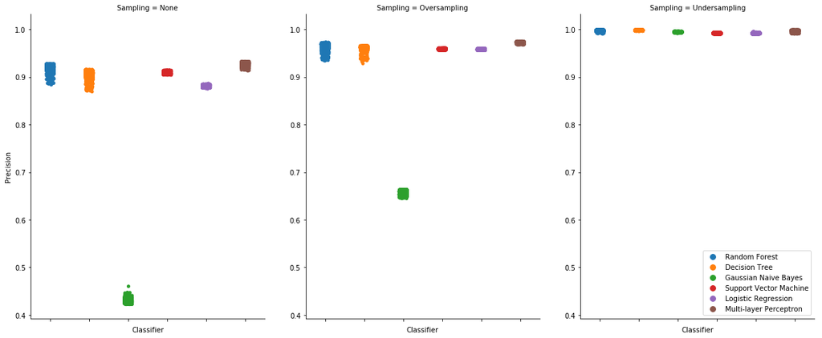

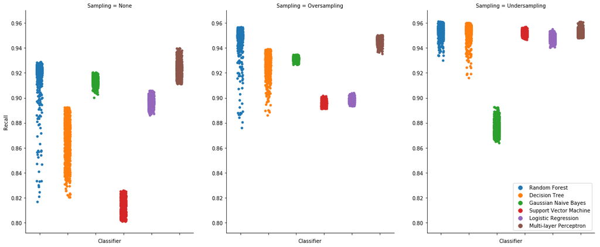

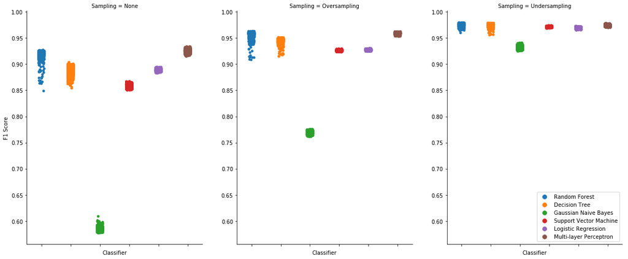

```python
import seaborn as sns
import matplotlib.pyplot as plt

plot_scores = ['precision_score', 'recall_score', 'f1_score']
ynames = ['Precision', 'Recall', 'F1 Score']
plot_metrics = [metrics, metrics_o, metrics_u]
plot_metrics_name = ['None', 'Oversampling', 'Undersampling']
plot_df = None

for plot_score, yname in zip(plot_scores, ynames):
    for current_metrics, current_metrics_name in zip(plot_metrics, plot_metrics_name):
        for classifier_index, classifier in enumerate(current_metrics.keys()):
            if classifier != '':
                current_plot_df = pd.DataFrame(
                    np.array(
                        [
                            np.array(current_metrics[classifier][plot_score]),
                            np.array([classifier_name_text[classifier_index]]*len(current_metrics[classifier][plot_score])),
                            np.array([current_metrics_name]*len(current_metrics[classifier][plot_score]))
                        ]
                    ).T,
                    columns=[plot_score, 'Classifier', 'Sampling']
                )
                if plot_df is None:
                    plot_df = current_plot_df
                else:
                    plot_df = plot_df.append(current_plot_df)
                plot_df[plot_score] = plot_df[plot_score].astype('double')

    g = sns.factorplot(x='Classifier', y=plot_score, hue='Classifier', data=plot_df, jitter=True, col="Sampling", legend=False, kind="strip", size=7, aspect=0.8, legend_out = True)
    plt.legend(loc='lower right')
    g.set_xticklabels('')
    g.set_ylabels(yname)
```

## Medians and 95% confidence intervals of precision, recall, F1 score

```python
scoring_types = ['precision_score', 'recall_score', 'f1_score']

for scoring_type in scoring_types:
    print(scoring_type)
    for classifier in metrics.keys():
        med_interval = np.percentile(metrics[classifier][scoring_type], [2.5, 50, 97.5])
        print(classifier + ' no_sampling: %.3f (%.3f - %.3f)' % (med_interval[1], med_interval[0], med_interval[2]))

        med_interval = np.percentile(metrics_o[classifier][scoring_type], [2.5, 50, 97.5])
        print(classifier + ' oversampling: %.3f (%.3f - %.3f)' % (med_interval[1], med_interval[0], med_interval[2]))

        med_interval = np.percentile(metrics_u[classifier][scoring_type], [2.5, 50, 97.5])
        print(classifier + ' undersampling: %.3f (%.3f - %.3f)' % (med_interval[1], med_interval[0], med_interval[2]))
    print('\n')
```

```
precision_score
RandomForestClassifier no_sampling: 0.921 (0.900 - 0.927)
RandomForestClassifier oversampling: 0.967 (0.946 - 0.970)
RandomForestClassifier undersampling: 0.997 (0.993 - 0.999)
DecisionTreeClassifier no_sampling: 0.908 (0.885 - 0.915)
DecisionTreeClassifier oversampling: 0.962 (0.949 - 0.965)
DecisionTreeClassifier undersampling: 0.998 (0.996 - 0.999)
GaussianNB no_sampling: 0.430 (0.424 - 0.438)
GaussianNB oversampling: 0.657 (0.648 - 0.663)
GaussianNB undersampling: 0.994 (0.993 - 0.995)
LinearSVC no_sampling: 0.908 (0.905 - 0.913)
LinearSVC oversampling: 0.959 (0.957 - 0.960)
LinearSVC undersampling: 0.991 (0.990 - 0.993)
LogisticRegression no_sampling: 0.881 (0.877 - 0.884)
LogisticRegression oversampling: 0.958 (0.956 - 0.959)
LogisticRegression undersampling: 0.991 (0.990 - 0.993)
MLPClassifier no_sampling: 0.926 (0.918 - 0.932)
MLPClassifier oversampling: 0.972 (0.969 - 0.974)
MLPClassifier undersampling: 0.997 (0.992 - 0.998)


recall_score
RandomForestClassifier no_sampling: 0.921 (0.881 - 0.926)
RandomForestClassifier oversampling: 0.950 (0.920 - 0.955)
RandomForestClassifier undersampling: 0.954 (0.943 - 0.960)
DecisionTreeClassifier no_sampling: 0.869 (0.834 - 0.890)
DecisionTreeClassifier oversampling: 0.930 (0.905 - 0.938)
DecisionTreeClassifier undersampling: 0.954 (0.936 - 0.959)
GaussianNB no_sampling: 0.914 (0.907 - 0.919)
GaussianNB oversampling: 0.931 (0.928 - 0.934)
GaussianNB undersampling: 0.875 (0.867 - 0.887)
LinearSVC no_sampling: 0.813 (0.802 - 0.823)
LinearSVC oversampling: 0.896 (0.892 - 0.900)
LinearSVC undersampling: 0.952 (0.949 - 0.955)
LogisticRegression no_sampling: 0.897 (0.890 - 0.904)
LogisticRegression oversampling: 0.898 (0.895 - 0.902)
LogisticRegression undersampling: 0.948 (0.943 - 0.952)
MLPClassifier no_sampling: 0.923 (0.913 - 0.934)
MLPClassifier oversampling: 0.946 (0.940 - 0.949)
MLPClassifier undersampling: 0.952 (0.949 - 0.957)


f1_score
RandomForestClassifier no_sampling: 0.921 (0.898 - 0.925)
RandomForestClassifier oversampling: 0.958 (0.942 - 0.962)
RandomForestClassifier undersampling: 0.975 (0.969 - 0.978)
DecisionTreeClassifier no_sampling: 0.887 (0.868 - 0.899)
DecisionTreeClassifier oversampling: 0.945 (0.930 - 0.950)
DecisionTreeClassifier undersampling: 0.975 (0.966 - 0.978)
GaussianNB no_sampling: 0.585 (0.579 - 0.593)
GaussianNB oversampling: 0.771 (0.764 - 0.775)
GaussianNB undersampling: 0.931 (0.926 - 0.938)
LinearSVC no_sampling: 0.858 (0.852 - 0.865)
LinearSVC oversampling: 0.926 (0.924 - 0.928)
LinearSVC undersampling: 0.971 (0.969 - 0.973)
LogisticRegression no_sampling: 0.889 (0.885 - 0.893)
LogisticRegression oversampling: 0.927 (0.925 - 0.929)
LogisticRegression undersampling: 0.969 (0.966 - 0.972)
MLPClassifier no_sampling: 0.924 (0.918 - 0.931)
MLPClassifier oversampling: 0.959 (0.955 - 0.961)
MLPClassifier undersampling: 0.974 (0.971 - 0.977)
```

## ROC curves and their AUCs

```
ROC Curves
```

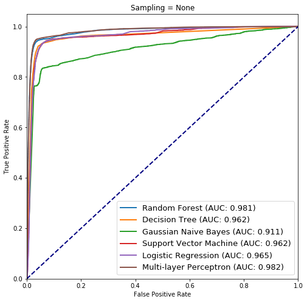

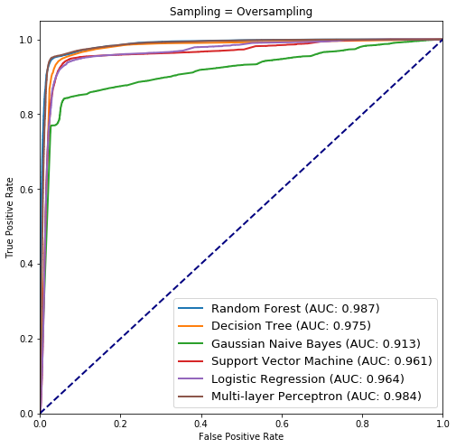

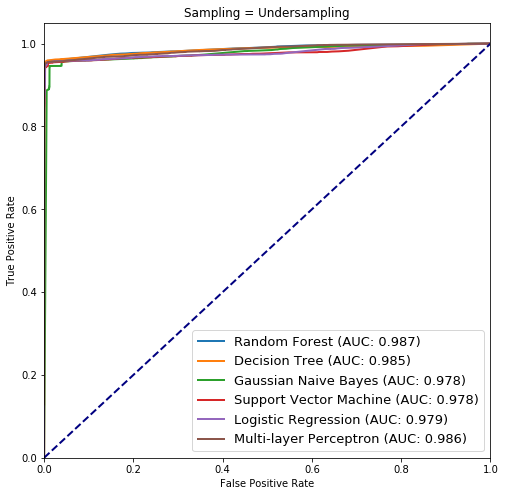

```python
targets = [metrics, metrics_o, metrics_u]
samplings = ['None', 'Oversampling', 'Undersampling']

print('ROC Curves')

for target, sampling in zip(targets, samplings):
    median_roc_curves = {k: None for k in target.keys()}

    for classifier in target.keys():
        target[classifier]['roc_auc'] = []
        for i in range(len(target[classifier]['roc_curve'])):
            fpr, tpr, _ = target[classifier]['roc_curve'][i]
            target[classifier]['roc_auc'].append(auc(fpr, tpr))

        median_index = np.argsort(target[classifier]['roc_auc'])[len(target[classifier]['roc_auc'])//2]
        median_roc_curves[classifier] = target[classifier]['roc_curve'][median_index]

    plt.figure(figsize=(8, 8))
    lw = 2
    for classifier_index, classifier in enumerate(median_roc_curves.keys()):
        fpr, tpr, _ = median_roc_curves[classifier]
        plt.plot(fpr, tpr, lw=lw, label=classifier_name_text[classifier_index] + ' (AUC: %.3f)' % auc(fpr, tpr))
    plt.plot([0, 1], [0, 1], color='navy', lw=lw, linestyle='--')
    plt.xlim([0.0, 1.0])
    plt.ylim([0.0, 1.05])
    plt.xlabel('False Positive Rate')
    plt.ylabel('True Positive Rate')
    plt.title('Sampling = %s' % sampling)
    plt.legend(loc="lower right", prop={'size': 13})
    plt.show()
```

## Precision-recall curves and their AUCs

```
Precision-Recall Curves
```

[figure not shown]

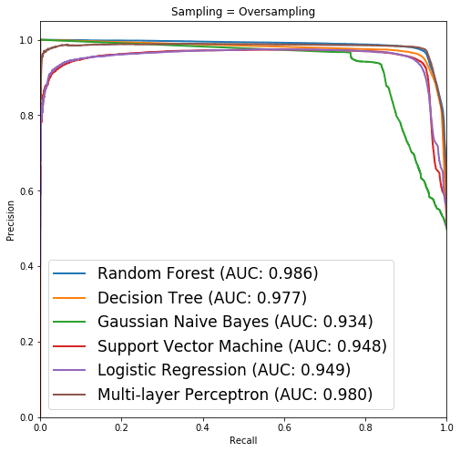

[figure not shown]

```python
targets = [metrics, metrics_o, metrics_u]
samplings = ['None', 'Oversampling', 'Undersampling']

print('Precision-Recall Curves')

for target, sampling in zip(targets, samplings):
    median_pr_curves = {k: None for k in target.keys()}

    for classifier in target.keys():
        target[classifier]['pr_auc'] = []
        for i in range(len(target[classifier]['precision_recall_curve'])):
            precision, recall, _ = target[classifier]['precision_recall_curve'][i]
            target[classifier]['pr_auc'].append(auc(recall, precision))

        median_index = np.argsort(target[classifier]['pr_auc'])[len(target[classifier]['pr_auc'])//2]
        median_pr_curves[classifier] = target[classifier]['precision_recall_curve'][median_index]

    plt.figure(figsize=(8, 8))
    lw = 2
    for classifier_index, classifier in enumerate(median_pr_curves.keys()):
        precision, recall, _ = median_pr_curves[classifier]
        plt.plot(recall, precision, lw=lw, label=classifier_name_text[classifier_index] + ' (AUC: %.3f)' % auc(recall, precision))
    plt.xlim([0.0, 1.0])
    plt.ylim([0.0, 1.05])
    plt.xlabel('Recall')
    plt.ylabel('Precision')
    plt.title('Sampling = Oversampling')
    plt.legend(loc="lower left", prop={'size': 17})
    plt.show()
```

## Conclusion

### Main observations

Based on the quantitative results, we conclude our study with recommendations for the research objective of building an effective machine learning pipeline to detect AF. There are two important notes:

1. **Undersampling**: We use NearMiss for undersampling and it has demonstrated significant improvement compared to oversampling with Synthetic Minority Over-sampling Technique (SMOTE). Moreover, undersampling has another advantage when it comes to training speed since the training data becomes much smaller. As a result, we use undersampling when making our classifier performance.
2. **Choice of metrics**: Precision and recall are suitable for our task, and should be used to dissect and understand different classifiers. As we weight these two metrics equally, we propose to use F1 Score for classifier assessment.

### Recommendations

As different classifiers have different advantages, we propose the most promising ones for our task according to different aspects:

- **Performance**: Random Forest.

- **Consistency**: MLP.

When it comes to consistency across different sampling settings, and different evaluation metrics, MLP is the classifier to be selected. Another characteristic of MLP is that it is has a lot of rooms for engineering, and the model can get relatively complex. Deep neural networks can even learn feature representations using their hidden layers for even more robust prediction. A trade-off for choosing MLP is the difficulty in tuning the model, and the slow training process.

- **Simplicity and interpretability**: Decision Tree.